# Business Understanding

## Business Proposal | The Battle of Neighborhoods

#### Introduction:

The objective of this project is to analizing Venues in Zurich Switzerland in order to asses the opportunity to open a new business depending on the postal code location / neigborhood. This projects will also explore the geographical location /neighborhoods and proximity to to the venues.

This particular project is in interest of people who want to invest in the Kanton of Zurich, Switzerland which is the Kanton with the biggest amount of population.

## Analytic Approach

This projects will also explore the geographical location /neighborhoods and proximito to the venues. Switzerland is a small country with around 8.5 million and composed of 26 Kantons , this Kanton are kind of states. Each of the Kanton has different dialacts and mix of poeple. In some of them German is the primarly language as is other is French or Italian. I will focus only in Zurich.

#### Scope:

This maps shows the ammount of zipcodes included

[figure not shown]

below is the selcted area to analize

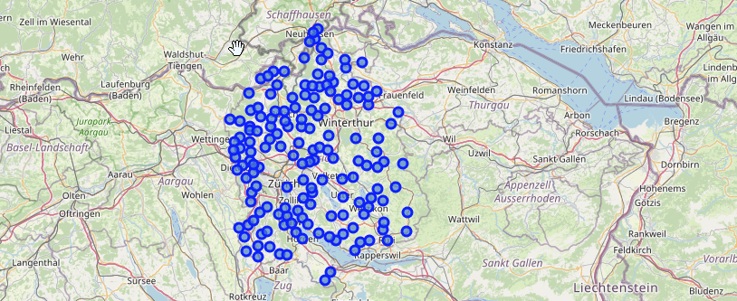

#### Work Flow:

This project would use Four-square API as its prime data gathering source as it has a database of millions of places, especially their places API which provides the ability to perform location search, location sharing and details about a business.

Ultimately i will cluster the results to determine the best ideas for a new business based on the most common venue and try to find out what kind of business are not existent in that areas.

#### Risk:

As im analizing an european country it maight be that Foursquare isnt the best source to get the right infro , but this is something i will have to asses once the project is done.

## Data Requirements

The main data: I will make use of the postal codes and the information from the Foursquare API for visual localization and ratings. The extend of this project will explore the different neigborhoods In Zurich as it is the most populated Kanton in switzerland. The coding is done is such a way that the different Kanton in switzerland can be analized separate by just changing the Kanton name.

Country info: https://en.wikipedia.org/wiki/Switzerland

- The main data will Postal code , exact location : latitude and longitude, name of the Kanton
- Foursquare will be all information possible from this location

## Data Collection

The Zurich geographical location will be utilized as input for the foursquare API. The geograpical coordinate of Zurich are 47.4133024, 8.656394.

The Zurich geographical location will be utilized as input for the foursquare API. The geograpical coordinate of Zurich are 47.4133024, 8.656394.

Postal codes: https://www.geonames.org/postalcode-search.html?q=&country=CH&adminCode1=

Foursquare API Data : https://foursquare.com/developers/apps

#### Libraries Used to Develope the Project:

Numpy: support for large, multi-dimensional arrays and matrices, along with a large collection of high-level mathematical functions

Geopy: client for several popular geocoding web services

Pandas: For creating and manipulating dataframes.

Folium: Python visualization library would be used to visualize the neighborhoods cluster distribution of using interactive leaflet map.

Scikit Learn: For importing k-means clustering.

JSON: Library to handle JSON files.

Geocoder: To retrieve Location Data.

Beautiful Soup and Requests: To scrap and library to handle http requests.

Matplotlib: Python Plotting Module.

## Data Understanding and Preparation

Here we do basic cleaning , eliminating the Nan , duplicates, giving names to the headers, etc. All the necesarry thing to merge after the two databases.

[figure not shown]